# UNIVERSIDAD SIMÓN BOLÍVAR Departamento de Tecnología y Electrónica EC7817 - Tópico especial II: Inteligencia Artificial en Biomédica

### $\rightarrow$ Transformación Box-Cox

Por último, se consideró el implementar la transformación Box-Cox, cuya expresión se muestra a continuación

\begin{align*} u = \begin{cases} \begin{array}{l} \ln(y) \quad sí \quad \lambda = 0 \\[5pt] \frac{(y^{\lambda}-1)}{\lambda} \quad sí \quad \lambda \neq 0 \end{array} \end{cases} \end{align*}

Aplicando dicha transformación a los atributos Whole_weight, Shucked_weight, Visera_weight, Shell_weight, se obtiene:

```python
#data7 = np.empty_like(data3)
#data7[:,:] = data3

data7 = np.copy(data3)

fitted_lambda = np.zeros((np.size(data3,1)))

data7[:,4], fitted_lambda[4] = stats.boxcox(data3[:,4])
data7[:,5], fitted_lambda[5] = stats.boxcox(data3[:,5])
data7[:,6], fitted_lambda[6] = stats.boxcox(data3[:,6])
data7[:,7], fitted_lambda[7] = stats.boxcox(data3[:,7])
```

[figure not shown]

```python
fig = plt.figure(figsize = (10, 6))
plt.hist( data7[:,7] , bins = 'auto' );
plt.title('Histograma del atributo Whole_weight aplicando la transformada Box-Cox')
plt.show()
```

Atributo Shucked_weight aplicando la transformada Box-Cox.

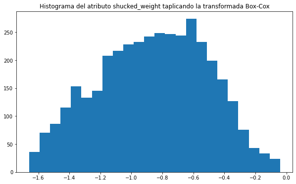

```python
fig = plt.figure(figsize = (10, 6))
plt.hist( data7[:,5] , bins = 'auto' );
plt.title('Histograma del atributo shucked_weight taplicando la transformada Box-Cox')
plt.show()
```

Atributo Visera_weight aplicando la transformada Box-Cox

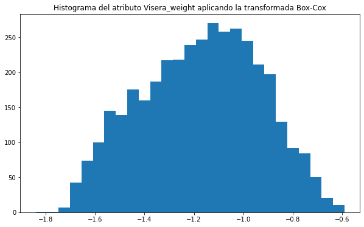

```python
fig = plt.figure(figsize = (10, 6))
plt.hist( data7[:,6] , bins = 'auto' );
plt.title('Histograma del atributo Visera_weight aplicando la transformada Box-Cox')
plt.show()
```

Atributo Shell_weight aplicando la transformada Box-Cox

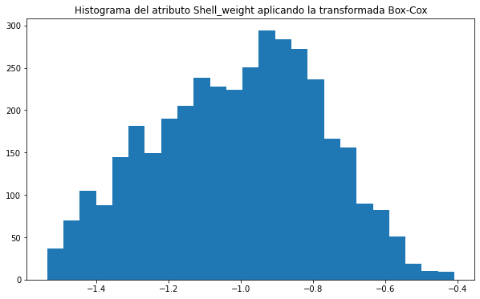

```python
fig = plt.figure(figsize = (10, 6))
plt.hist( data7[:,7] , bins = 'auto' );
plt.title('Histograma del atributo Shell_weight aplicando la transformada Box-Cox')
plt.show()
```

Claramente se puede apreciar que la transformación Box-Cox arroja distribuciones más cercanas a una distribución gaussiana.

Aplicando dicha transformación sobre los 3 atributos restantes (Length, Diameter y Height), se tiene:

```python
data7[:,1], fitted_lambda[1] = stats.boxcox(data3[:,1])
data7[:,2], fitted_lambda[2] = stats.boxcox(data3[:,2])
data7[:,3], fitted_lambda[3] = stats.boxcox(data3[:,3])
```

Atributo Length aplicando la transformada Box-Cox

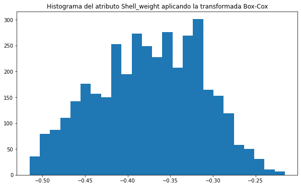

```python
fig = plt.figure(figsize = (10, 6))
plt.hist( data7[:,1] , bins = 'auto' );
plt.title('Histograma del atributo Shell_weight aplicando la transformada Box-Cox')
plt.show()
```

Atributo Diameter aplicando la transformada Box-Cox

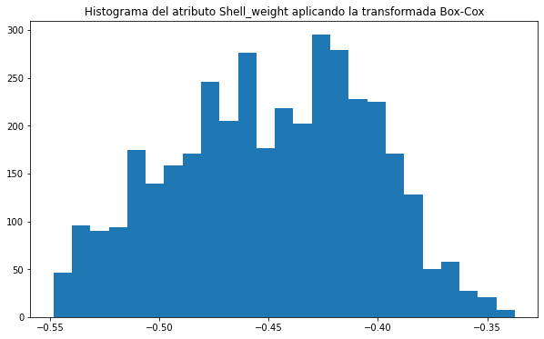

```python
fig = plt.figure(figsize = (10, 6))
plt.hist( data7[:,2] , bins = 'auto' );
plt.title('Histograma del atributo Shell_weight aplicando la transformada Box-Cox')
plt.show()
```

Atributo Height aplicando la transformada Box-Cox

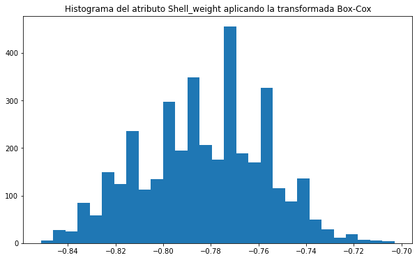

```python
fig = plt.figure(figsize = (10, 6))
plt.hist( data7[:,3] , bins = 'auto' );
plt.title('Histograma del atributo Shell_weight aplicando la transformada Box-Cox')
plt.show()
```

Como se puede apreciar, se obtiene una ligera mejoría en la distribución de datos de las variables 'Length', 'Diameter' y 'Height' aplicando la transformada Box-Cox sobre éstas.

Los valores obtenidos de los parámetros de interés para los datos sometidos a la tranformación Box-Cox se muestran a continuación.

```python
#cálculo de los parámetros estadísticos

Data7Mean = np.mean(data7, axis = 0)
Data7Median = np.median(data7, axis = 0)
Data7Mode = stats.mode(data7, axis = 0)
Data7Max = np.max(data7, axis = 0)
Data7Min = np.min(data7, axis = 0)
Data7Range = Data7Max - Data7Min
Data7Desv = np.std(data7, axis = 0)
Data7Skew = stats.skew(data7, axis = 0, bias = 0)
Data7Kurt = stats.kurtosis(data7, axis = 0, bias = 0)
```

```python
#Presentación de los valores de los parámetros estadísticos estudiados

print('la media de los atributos transformandos con Box-Cox es:');
print(Data7Mean);
print();
print('la mediana de los atributos transformandos con Box-Cox es:');
print(Data7Median);
print();
print('la moda de los atributos transformandos con Box-Cox es:');
print(Data7Mode);
print();
print('el valor máximo de los atributos transformandos con Box-Cox es:');
print(Data7Max);
print();
print('el valor mínimo de los atributos transformandos con Box-Cox es:');
print(Data7Min);
print();
print('lel rango de los atributos transformandos con Box-Cox es:');
print(Data7Range);
print();
print('la desviación estándar de los atributos transformandos con Box-Cox es:');
print(Data7Desv);
print();
print('la asimetría de los atributos transformandos con Box-Cox es:');
print(Data7Skew);
print();
print('el curtosis de los atributos transformandos con Box-Cox es:');
print(Data7Kurt);
print();
```

```
la media de los atributos transformandos con Box-Cox es:
[ 0.02618355 -0.37429714 -0.44923381 -0.78283052 -0.28389804 -0.85986133
 -1.17246937 -1.00827998  9.43057392]

la mediana de los atributos transformandos con Box-Cox es:
[ 0.         -0.37194064 -0.44559486 -0.78133415 -0.24632203 -0.84175878
 -1.15950397 -0.99211595  9.        ]

la moda de los atributos transformandos con Box-Cox es:
ModeResult(mode=array([[ 1.        , -0.31486558, -0.4295832 , -0.77377901, -1.00084226,
        -1.13439466, -1.14226961, -0.89641613,  9.        ]]), count=array([[1360,   89,  129,  255,    8,   11,   15,   40,  685]]))

el valor máximo de los atributos transformandos con Box-Cox es:
[ 1.         -0.21558696 -0.33737971 -0.70287203  0.94852647 -0.04038032
 -0.59042323 -0.40916605 15.        ]

el valor mínimo de los atributos transformandos con Box-Cox es:
[-1.         -0.51501669 -0.54839027 -0.85134036 -1.44265423 -1.66021343
 -1.84032925 -1.53515665  4.        ]

lel rango de los atributos transformandos con Box-Cox es:
[ 2.          0.29942974  0.21101055  0.14846833  2.3911807   1.61983311
  1.24990601  1.1259906  11.        ]

la desviación estándar de los atributos transformandos con Box-Cox es:
[0.83217623 0.06197681 0.04475877 0.02629157 0.51460648 0.35070216
 0.2409268  0.23114727 2.33013364]

la asimetría de los atributos transformandos con Box-Cox es:
[-0.04900827 -0.12738934 -0.13477452 -0.06390032 -0.12853352 -0.11413007
 -0.11322562 -0.11972264  0.26920452]

el curtosis de los atributos transformandos con Box-Cox es:
[-1.55480736 -0.74652043 -0.76489945 -0.4929999  -0.78182313 -0.73667595
 -0.73430947 -0.71107438 -0.21464546]
```

### Normalización de los datos transformados con Box-Cox

Posterior a la transformación de los datos, se procede a la normalización de los mismos. Esto se realiza en este orden para asegurar la estandarización (en términos de rango y orden de magnitud) de los datos transformados.

La metodología de normalización será la técnica Z-Score. La ecuación corresponde a:

\begin{align*} x_N = \frac{(x - \mu)}{ \sigma } \end{align*}

La misma se implementará solo en los atributos de entrada de naturaleza continua.

```python
#Aplicando la normalización Z-Score para todos los atributo excepto Sex y Rings.

data7N = np.empty_like(data3)

data7N = data7;

data7N[:,1:8] = (data7N[:,1:8] - ( Data7Mean[1:8].transpose() * np.ones( (np.size(data7N[:,1:8],0),np.size(data7N[:,1:8],1)) ) )  ) / ( Data7Desv[1:8].transpose()  * np.ones( (np.size(data7N[:,1:8],0), np.size(data7N[:,1:8],1)) ) )
```

Se procede a mostrar los histogramas de las variables normalizadas.

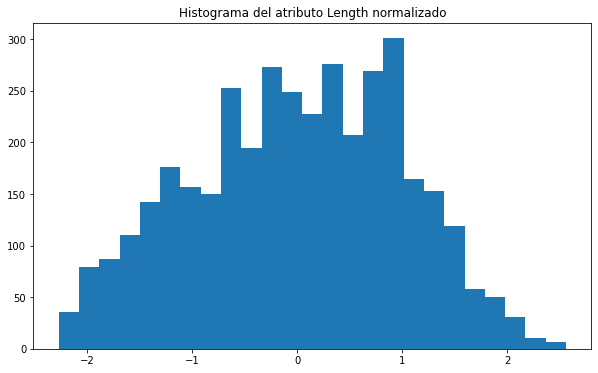

```python
fig = plt.figure(figsize = (10, 6))
plt.hist( data7N[:,1] , bins = 'auto' );
plt.title('Histograma del atributo Length normalizado')
plt.show()
```

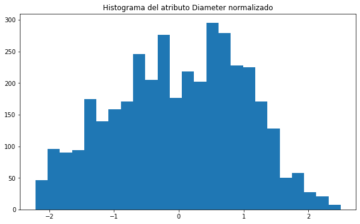

```python
fig = plt.figure(figsize = (10, 6))
plt.hist( data7N[:,2] , bins = 'auto' );
plt.title('Histograma del atributo Diameter normalizado')
plt.show()
```

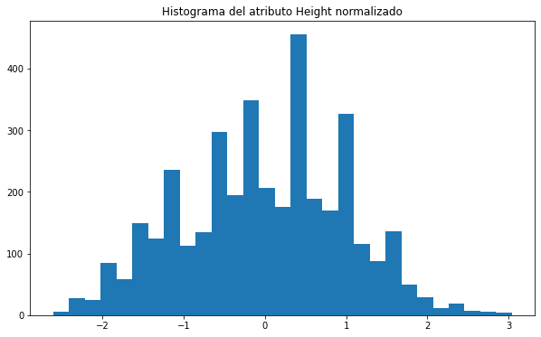

```python
fig = plt.figure(figsize = (10, 6))
plt.hist( data7N[:,3] , bins = 'auto' );
plt.title('Histograma del atributo Height normalizado')
plt.show()
```

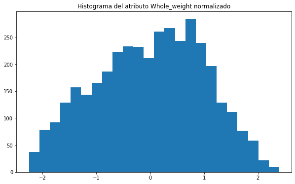

```python
fig = plt.figure(figsize = (10, 6))
plt.hist( data7N[:,4] , bins = 'auto' );
plt.title('Histograma del atributo Whole_weight normalizado')
plt.show()
```

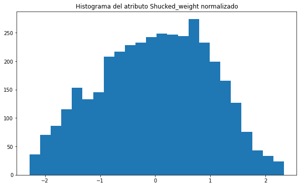

```python
fig = plt.figure(figsize = (10, 6))
plt.hist( data7N[:,5] , bins = 'auto' );
plt.title('Histograma del atributo Shucked_weight normalizado')
plt.show()
```

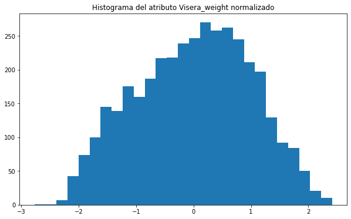

```python
fig = plt.figure(figsize = (10, 6))
plt.hist( data7N[:,6] , bins = 'auto' );
plt.title('Histograma del atributo Visera_weight normalizado')
plt.show()
```

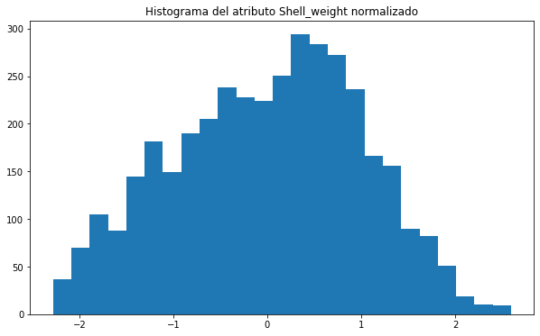

```python
fig = plt.figure(figsize = (10, 6))
plt.hist( data7N[:,7] , bins = 'auto' );
plt.title('Histograma del atributo Shell_weight normalizado')
plt.show()
```

Lo relevante es que todos los valores de todos los atributos continuos tienen el mismo orden de magnitud dentro del mismo rango ($[ -2.698 \sigma , 2698 \sigma ]$).

### $\rightarrow$ Cálculo de los parámetros estadísticos de los datos normalizados.

Por último, se recalculan los valores de los parámetros estadísticos para los datos normalizados

```python
#cálculo de los parámetros estadísticos

Data7NMean = np.mean(data7N, axis = 0)
Data7NMedian = np.median(data7N, axis = 0)
Data7NMode = stats.mode(data7N, axis = 0)
Data7NMax = np.max(data7N, axis = 0)
Data7NMin = np.min(data7N, axis = 0)
Data7NRange = Data7NMax - Data7NMin
Data7NDesv = np.std(data7N, axis = 0)
Data7NSkew = stats.skew(data7N, axis = 0, bias = 0)
Data7NKurt = stats.kurtosis(data7N, axis = 0, bias = 0)
```

```python
#Presentación de los valores de los parámetros estadísticos estudiados

print('la media de los atributos normalizados con Box-Cox es:');
print(Data7NMean);
print();
print('la mediana de los atributos normalizandos con Box-Cox es:');
print(Data7NMedian);
print();
print('la moda de los atributos normalizandos con Box-Cox es:');
print(Data7NMode);
print();
print('el valor máximo de los atributos normalizandos con Box-Cox es:');
print(Data7NMax);
print();
print('el valor mínimo de los atributos normalizandos con Box-Cox es:');
print(Data7NMin);
print();
print('lel rango de los atributos normalizandos con Box-Cox es:');
print(Data7NRange);
print();
print('la desviación estándar de los atributos normalizandos con Box-Cox es:');
print(Data7NDesv);
print();
print('la asimetría de los atributos normalizandos con Box-Cox es:');
print(Data7NSkew);
print();
print('el curtosis de los atributos normalizandos con Box-Cox es:');
print(Data7NKurt);
print();
```

```
la media de los atributos normalizados con Box-Cox es:
[ 2.61835493e-02 -2.52917085e-15 -7.32637378e-14  1.77313158e-13
 -3.01853814e-17  3.53885424e-15  5.72570878e-15  8.74318984e-16
  9.43057392e+00]

la mediana de los atributos normalizandos con Box-Cox es:
[0.         0.03802239 0.0813012  0.0569143  0.07301892 0.05161802
 0.0538147  0.06992956 9.        ]

la moda de los atributos normalizandos con Box-Cox es:
ModeResult(mode=array([[ 1.        ,  0.95893217,  0.43903373,  0.34427402, -1.39318925,
        -0.78281047,  0.12534829,  0.48395057,  9.        ]]), count=array([[1360,   89,  129,  255,    8,   11,   15,   40,  685]]))

el valor máximo de los atributos normalizandos con Box-Cox es:
[ 1.          2.56079937  2.49904296  3.04122157  2.39488729  2.33668652
  2.41586295  2.59191436 15.        ]

el valor mínimo de los atributos normalizandos con Box-Cox es:
[-1.         -2.27051927 -2.2153526  -2.6057724  -2.2517326  -2.2821419
 -2.77204472 -2.27939825  4.        ]

lel rango de los atributos normalizandos con Box-Cox es:
[ 2.          4.83131864  4.71439556  5.64699397  4.6466199   4.61882842
  5.18790766  4.87131261 11.        ]

la desviación estándar de los atributos normalizandos con Box-Cox es:
[0.83217623 1.         1.         1.         1.         1.
 1.         1.         2.33013364]

la asimetría de los atributos normalizandos con Box-Cox es:
[-0.04900827 -0.12738934 -0.13477452 -0.06390032 -0.12853352 -0.11413007
 -0.11322562 -0.11972264  0.26920452]

el curtosis de los atributos normalizandos con Box-Cox es:
[-1.55480736 -0.74652043 -0.76489945 -0.4929999  -0.78182313 -0.73667595
 -0.73430947 -0.71107438 -0.21464546]
```

## Estudio del comportamiento entre los datos

Con los datos transformados y normalizados, se procede a graficar los diagramas de dispersión (scatter plots) de cada una de los atributos a considerar como variables (Sex, Length, Diameter, Whole_weight, Shucked_weight, Visera_weight y Shell_weight) respecto al atributo a considerar como salida del sistema (Rigns).

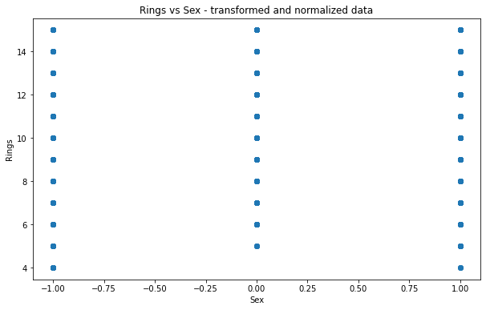

```python
#Scatter plot Rings vs Sex

fig = plt.figure(figsize = (10, 6))
plt.scatter(data7N[:,0], data7N[:,8])
plt.title('Rings vs Sex - transformed and normalized data')
plt.xlabel('Sex')
plt.ylabel('Rings')
plt.show()
```

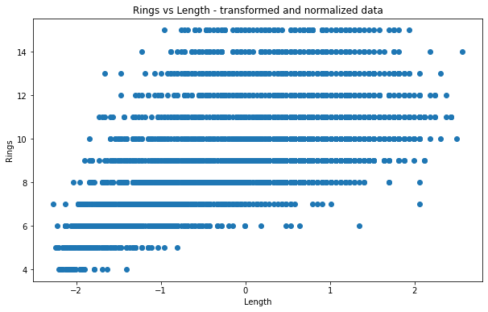

```python
#Scatter plot Rings vs Length

fig = plt.figure(figsize = (10, 6))
plt.scatter(data7N[:,1], data7N[:,8])
plt.title('Rings vs Length - transformed and normalized data')
plt.xlabel('Length')
plt.ylabel('Rings')
plt.show()
```

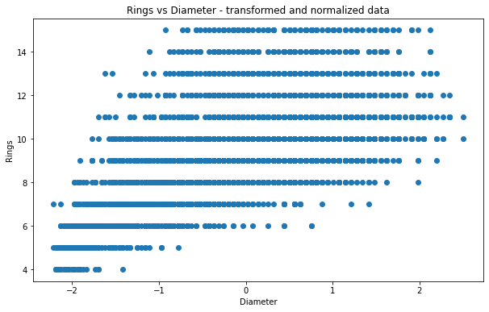

```python
#Scatter plot Rings vs Diameter

fig = plt.figure(figsize = (10, 6))
plt.scatter(data7N[:,2], data7N[:,8])
plt.title('Rings vs Diameter - transformed and normalized data')
plt.xlabel('Diameter')
plt.ylabel('Rings')
plt.show()
```

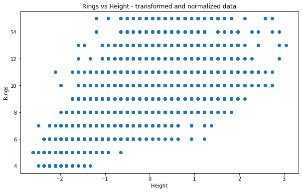

```python
#Scatter plot Rings vs Height

fig = plt.figure(figsize = (10, 6))
plt.scatter(data7N[:,3], data7N[:,8])
plt.title('Rings vs Height - transformed and normalized data')
plt.xlabel('Height')
plt.ylabel('Rings')
plt.show()
```

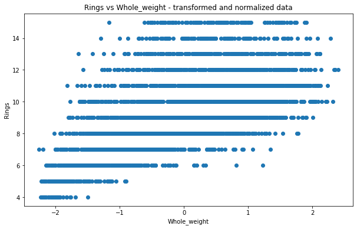

```python
#Scatter plot Rings vs Whole_weight

fig = plt.figure(figsize = (10, 6))
plt.scatter(data7N[:,4], data7N[:,8])
plt.title('Rings vs Whole_weight - transformed and normalized data')
plt.xlabel('Whole_weight')
plt.ylabel('Rings')
plt.show()
```

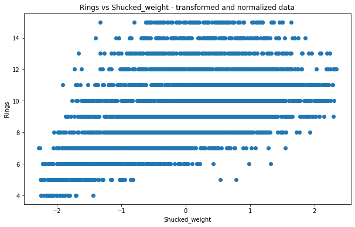

```python
#Scatter plot Rings vs Shucked_weight

fig = plt.figure(figsize = (10, 6))
plt.scatter(data7N[:,5], data7N[:,8])
plt.title('Rings vs Shucked_weight - transformed and normalized data')
plt.xlabel('Shucked_weight')
plt.ylabel('Rings')
plt.show()
```

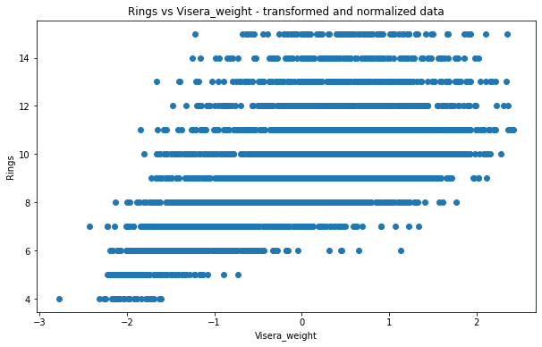

```python
#Scatter plot Rings vs Visera_weight

fig = plt.figure(figsize = (10, 6))
plt.scatter(data7N[:,6], data7N[:,8])
plt.title('Rings vs Visera_weight - transformed and normalized data')
plt.xlabel('Visera_weight')
plt.ylabel('Rings')
plt.show()
```

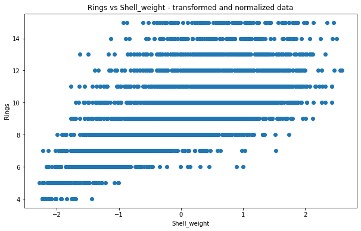

```python
#Scatter plot Rings vs Shell_weight

fig = plt.figure(figsize = (10, 6))
plt.scatter(data7N[:,7], data7N[:,8])
plt.title('Rings vs Shell_weight - transformed and normalized data')
plt.xlabel('Shell_weight')
plt.ylabel('Rings')
plt.show()
```

De los diagramas de dispersión presentados anteriormente, se puede observar que, para casi todos los valores de cada atributo normalizado, existe una correspondencia con varios valores de Rings cuando estos son mayores a 6, mientras que para valores de 4, solo unos pocos datos corresponden.

Esto afecta el desempeño del modelo, debido a que claramente no puede ser descrito como una recta y, adicionalmente, existen muchas combinaciones de diferentes valores de los atributos de entradas que corresponden a un mismo valor del atributo Rings, lo que sugiere un comportamiento no lineal.

Con base en lo anteriormente mencionado, resultará necesario el realizar combinaciones de inputs para mejorar el desempeño de la regresión lineal.

### Correlación entre variables

Se debe evaluar, dentro del estudio estadístico de los atributos, la correlación que existe entre ellos.

Para medir la correlación entre los atributos de entrada y el atributo de salida, se procede a implementar la correlación de Pearson.

```python
#Correlaciones de Pearson de todos los atributos de entrada con el atributo de salida.

#corrData = np.corrcoef([data7N[:,0],data7N[:,8]])

corrData = np.corrcoef(np.transpose(data7N))

#print(corrData)
```

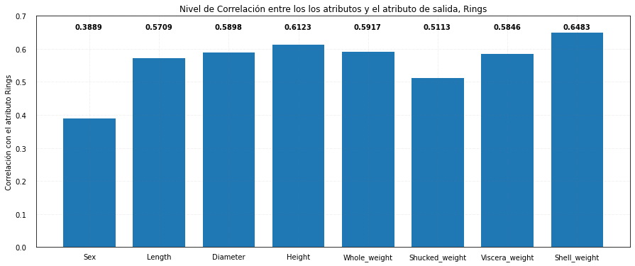

```python
#print(list(varnames[0:8]))
#print(list(corrData[:,8]))

#Figure size
fig, ax = plt.subplots(figsize = (15, 6))

# Bar Plot
ax.bar(list(varnames[0:8]), list(corrData[0:8,8]), width = 0.75);

# Remove x, y Ticks
ax.xaxis.set_ticks_position('none')
ax.yaxis.set_ticks_position('none')

# Add padding between axes and labels
ax.xaxis.set_tick_params(pad = 5)
ax.yaxis.set_tick_params(pad = 10)

# Add x, y gridlines
ax.grid(b = True, color ='grey', linestyle ='-.', linewidth = 0.5, alpha = 0.2)

# Add annotation to bars
j = 0
for i in ax.patches:
    plt.text(i.get_x() + 0.17, i.get_y() + np.round( np.max( corrData[0:8,8] ), 1 ) + 0.06, str( np.round( corrData[j,8] , 4) ), fontsize = 10, fontweight ='bold', color ='black');
    j = j + 1

# Plot title
ax.set_title('Nivel de Correlación entre los los atributos y el atributo de salida, Rings')

# y axis configuration
ax.set_ylim( [0, np.round( np.max( corrData[0:8,8] ) + 0.1, 1 )] )
ax.set_ylabel('Correlación con el atributo Rings')

#fig.text(0.9, 0.15, 'Jeeteshgavande30', fontsize = 12, color ='grey', ha ='right', va ='bottom', alpha = 0.7)

plt.show()
```

A continuación, se pretende calcular la correlación de los atributos considerados como variables de entrada entre ellos, de modo de detectar la influencia que arroja el uso de cada una al problema.

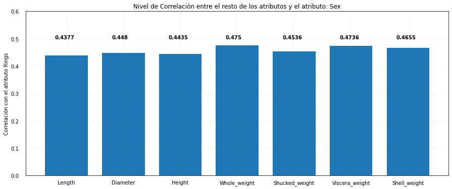

```python
#Se definen los vectores a graficar
aux = np.round(np.copy(corrData[0:8,0]), 15)
auxnames = np.copy(varnames[0:8])

auxAtr = auxnames[aux[:] == 1.];
auxnames = np.delete(auxnames, aux[:] == 1.);
aux = np.delete(aux, aux[:] == 1.);


# Figure size
fig, ax = plt.subplots(figsize = (15, 6))

# Bar Plot
ax.bar(list(auxnames), list(aux), width = 0.75);

# Remove x, y Ticks
ax.xaxis.set_ticks_position('none')
ax.yaxis.set_ticks_position('none')

# Add padding between axes and labels
ax.xaxis.set_tick_params(pad = 5)
ax.yaxis.set_tick_params(pad = 10)

# Add x, y gridlines
ax.grid(b = True, color ='grey', linestyle ='-.', linewidth = 0.5, alpha = 0.2)

# Add annotation to bars
j = 0
for i in ax.patches:
    plt.text(i.get_x()+0.17, i.get_y() + np.round( np.max( aux ), 1 ), str( np.round( aux[j] , 4) ), fontsize = 10, fontweight ='bold', color ='black');
    j = j + 1

# Plot title
ax.set_title('Nivel de Correlación entre el resto de los atributos y el atributo: ' + auxAtr[0])

# y axis configuration
ax.set_ylim( [0, np.round( np.max( aux ) + 0.1, 1 )] )
ax.set_ylabel('Correlación con el atributo Rings')

#fig.text(0.9, 0.15, 'Jeeteshgavande30', fontsize = 12, color ='grey', ha ='right', va ='bottom', alpha = 0.7)

plt.show()
```

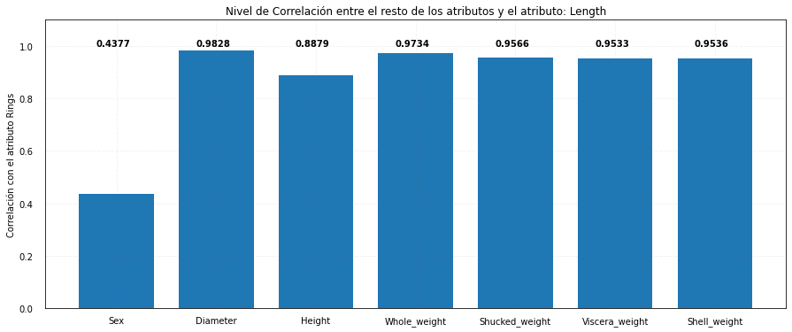

```python
#Se definen los vectores a graficar
aux = np.copy(corrData[0:8,1])
auxnames = np.copy(varnames[0:8])

auxAtr = auxnames[aux[:] == 1.0]
auxnames = np.delete(auxnames, aux[:] == 1.0);
aux = np.delete(aux, aux[:] == 1.0);


# Figure size
fig, ax = plt.subplots(figsize = (15, 6))

# Bar Plot
ax.bar(list(auxnames), list(aux), width = 0.75);

# Remove x, y Ticks
ax.xaxis.set_ticks_position('none')
ax.yaxis.set_ticks_position('none')

# Add padding between axes and labels
ax.xaxis.set_tick_params(pad = 5)
ax.yaxis.set_tick_params(pad = 10)

# Add x, y gridlines
ax.grid(b = True, color ='grey', linestyle ='-.', linewidth = 0.5, alpha = 0.2)

# Add annotation to bars
j = 0
for i in ax.patches:
    plt.text(i.get_x()+0.17, i.get_y() + np.round( np.max( aux ), 1 ), str( np.round( aux[j] , 4) ), fontsize = 10, fontweight ='bold', color ='black');
    j = j + 1

# Plot title
ax.set_title('Nivel de Correlación entre el resto de los atributos y el atributo: ' + auxAtr[0])

# y axis configuration
ax.set_ylim( [0, np.round( np.max( aux ) + 0.1, 1 )] )
ax.set_ylabel('Correlación con el atributo Rings')

#fig.text(0.9, 0.15, 'Jeeteshgavande30', fontsize = 12, color ='grey', ha ='right', va ='bottom', alpha = 0.7)

plt.show()
```

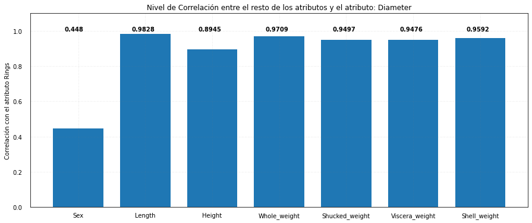

```python
#Se definen los vectores a graficar
aux = np.copy(corrData[0:8,2])
auxnames = np.copy(varnames[0:8])

auxAtr = auxnames[aux[:] == 1.0]
auxnames = np.delete(auxnames, aux[:] == 1.0);
aux = np.delete(aux, aux[:] == 1.0);


# Figure size
fig, ax = plt.subplots(figsize = (15, 6))

# Bar Plot
ax.bar(list(auxnames), list(aux), width = 0.75);

# Remove x, y Ticks
ax.xaxis.set_ticks_position('none')
ax.yaxis.set_ticks_position('none')

# Add padding between axes and labels
ax.xaxis.set_tick_params(pad = 5)
ax.yaxis.set_tick_params(pad = 10)

# Add x, y gridlines
ax.grid(b = True, color ='grey', linestyle ='-.', linewidth = 0.5, alpha = 0.2)

# Add annotation to bars
j = 0
for i in ax.patches:
    plt.text(i.get_x()+0.17, i.get_y() + np.round( np.max( aux ), 1 ), str( np.round( aux[j] , 4) ), fontsize = 10, fontweight ='bold', color ='black');
    j = j + 1

# Plot title
ax.set_title('Nivel de Correlación entre el resto de los atributos y el atributo: ' + auxAtr[0])

# y axis configuration
ax.set_ylim( [0, np.round( np.max( aux ) + 0.1, 1 )] )
ax.set_ylabel('Correlación con el atributo Rings')

#fig.text(0.9, 0.15, 'Jeeteshgavande30', fontsize = 12, color ='grey', ha ='right', va ='bottom', alpha = 0.7)

plt.show()
```

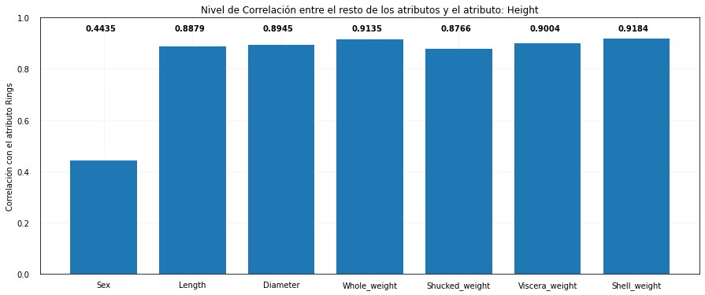

```python
#Se definen los vectores a graficar
aux = np.copy(corrData[0:8,3])
auxnames = np.copy(varnames[0:8])

auxAtr = auxnames[aux[:] == 1.0]
auxnames = np.delete(auxnames, aux[:] == 1.0);
aux = np.delete(aux, aux[:] == 1.0);


# Figure size
fig, ax = plt.subplots(figsize = (15, 6))

# Bar Plot
ax.bar(list(auxnames), list(aux), width = 0.75);

# Remove x, y Ticks
ax.xaxis.set_ticks_position('none')
ax.yaxis.set_ticks_position('none')

# Add padding between axes and labels
ax.xaxis.set_tick_params(pad = 5)
ax.yaxis.set_tick_params(pad = 10)

# Add x, y gridlines
ax.grid(b = True, color ='grey', linestyle ='-.', linewidth = 0.5, alpha = 0.2)

# Add annotation to bars
j = 0
for i in ax.patches:
    plt.text(i.get_x()+0.17, i.get_y() + np.round( np.max( aux ), 1 ) + 0.05, str( np.round( aux[j] , 4) ), fontsize = 10, fontweight ='bold', color ='black');
    j = j + 1

# Plot title
ax.set_title('Nivel de Correlación entre el resto de los atributos y el atributo: ' + auxAtr[0])

# y axis configuration
ax.set_ylim( [0, np.round( np.max( aux ) + 0.1, 1 )] )
ax.set_ylabel('Correlación con el atributo Rings')

#fig.text(0.9, 0.15, 'Jeeteshgavande30', fontsize = 12, color ='grey', ha ='right', va ='bottom', alpha = 0.7)

plt.show()
```

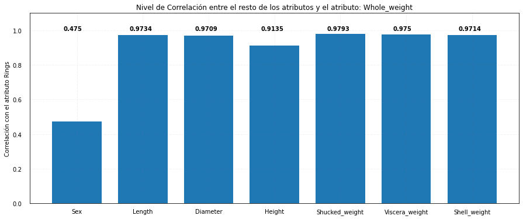

```python
#Se definen los vectores a graficar
aux = np.copy(corrData[0:8,4])
auxnames = np.copy(varnames[0:8])

auxAtr = auxnames[aux[:] == 1.0]
auxnames = np.delete(auxnames, aux[:] == 1.0);
aux = np.delete(aux, aux[:] == 1.0);


# Figure size
fig, ax = plt.subplots(figsize = (15, 6))

# Bar Plot
ax.bar(list(auxnames), list(aux), width = 0.75);

# Remove x, y Ticks
ax.xaxis.set_ticks_position('none')
ax.yaxis.set_ticks_position('none')

# Add padding between axes and labels
ax.xaxis.set_tick_params(pad = 5)
ax.yaxis.set_tick_params(pad = 10)

# Add x, y gridlines
ax.grid(b = True, color ='grey', linestyle ='-.', linewidth = 0.5, alpha = 0.2)

# Add annotation to bars
j = 0
for i in ax.patches:
    plt.text(i.get_x()+0.17, i.get_y() + np.round( np.max( aux ), 1 ), str( np.round( aux[j] , 4) ), fontsize = 10, fontweight ='bold', color ='black');
    j = j + 1

# Plot title
ax.set_title('Nivel de Correlación entre el resto de los atributos y el atributo: ' + auxAtr[0])

# y axis configuration
ax.set_ylim( [0, np.round( np.max( aux ) + 0.1, 1 )] )
ax.set_ylabel('Correlación con el atributo Rings')

#fig.text(0.9, 0.15, 'Jeeteshgavande30', fontsize = 12, color ='grey', ha ='right', va ='bottom', alpha = 0.7)

plt.show()
```

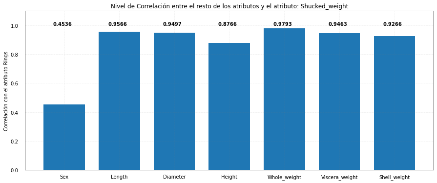

```python
#Se definen los vectores a graficar
aux = np.copy(corrData[0:8,5])
auxnames = np.copy(varnames[0:8])

auxAtr = auxnames[aux[:] == 1.0]
auxnames = np.delete(auxnames, aux[:] == 1.0);
aux = np.delete(aux, aux[:] == 1.0);


# Figure size
fig, ax = plt.subplots(figsize = (15, 6))

# Bar Plot
ax.bar(list(auxnames), list(aux), width = 0.75);

# Remove x, y Ticks
ax.xaxis.set_ticks_position('none')
ax.yaxis.set_ticks_position('none')

# Add padding between axes and labels
ax.xaxis.set_tick_params(pad = 5)
ax.yaxis.set_tick_params(pad = 10)

# Add x, y gridlines
ax.grid(b = True, color ='grey', linestyle ='-.', linewidth = 0.5, alpha = 0.2)

# Add annotation to bars
j = 0
for i in ax.patches:
    plt.text(i.get_x()+0.17, i.get_y() + np.round( np.max( aux ), 1 ), str( np.round( aux[j] , 4) ), fontsize = 10, fontweight ='bold', color ='black');
    j = j + 1

# Plot title
ax.set_title('Nivel de Correlación entre el resto de los atributos y el atributo: ' + auxAtr[0])

# y axis configuration
ax.set_ylim( [0, np.round( np.max( aux ) + 0.1, 1 )] )
ax.set_ylabel('Correlación con el atributo Rings')

#fig.text(0.9, 0.15, 'Jeeteshgavande30', fontsize = 12, color ='grey', ha ='right', va ='bottom', alpha = 0.7)

plt.show()
```

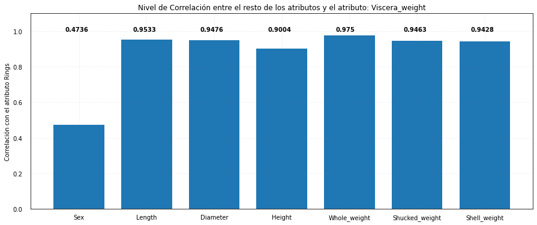

```python
#Se definen los vectores a graficar
aux = np.copy(corrData[0:8,6])
auxnames = np.copy(varnames[0:8])

auxAtr = auxnames[aux[:] == 1.0]
auxnames = np.delete(auxnames, aux[:] == 1.0);
aux = np.delete(aux, aux[:] == 1.0);


# Figure size
fig, ax = plt.subplots(figsize = (15, 6))

# Bar Plot
ax.bar(list(auxnames), list(aux), width = 0.75);

# Remove x, y Ticks
ax.xaxis.set_ticks_position('none')
ax.yaxis.set_ticks_position('none')

# Add padding between axes and labels
ax.xaxis.set_tick_params(pad = 5)
ax.yaxis.set_tick_params(pad = 10)

# Add x, y gridlines
ax.grid(b = True, color ='grey', linestyle ='-.', linewidth = 0.5, alpha = 0.2)

# Add annotation to bars
j = 0
for i in ax.patches:
    plt.text(i.get_x()+0.17, i.get_y() + np.round( np.max( aux ), 1 ), str( np.round( aux[j] , 4) ), fontsize = 10, fontweight ='bold', color ='black');
    j = j + 1

# Plot title
ax.set_title('Nivel de Correlación entre el resto de los atributos y el atributo: ' + auxAtr[0])

# y axis configuration
ax.set_ylim( [0, np.round( np.max( aux ) + 0.1, 1 )] )
ax.set_ylabel('Correlación con el atributo Rings')

#fig.text(0.9, 0.15, 'Jeeteshgavande30', fontsize = 12, color ='grey', ha ='right', va ='bottom', alpha = 0.7)

plt.show()
```

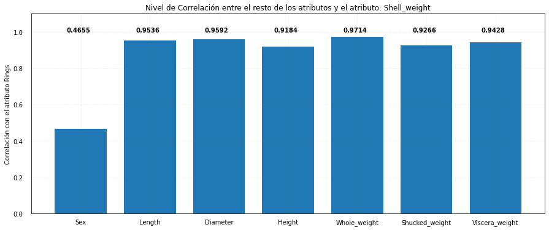

```python
#Se definen los vectores a graficar
aux = np.copy(corrData[0:8,7])
auxnames = np.copy(varnames[0:8])

auxAtr = auxnames[aux[:] == 1.0]
auxnames = np.delete(auxnames, aux[:] == 1.0);
aux = np.delete(aux, aux[:] == 1.0);


# Figure size
fig, ax = plt.subplots(figsize = (15, 6))

# Bar Plot
ax.bar(list(auxnames), list(aux), width = 0.75);

# Remove x, y Ticks
ax.xaxis.set_ticks_position('none')
ax.yaxis.set_ticks_position('none')

# Add padding between axes and labels
ax.xaxis.set_tick_params(pad = 5)
ax.yaxis.set_tick_params(pad = 10)

# Add x, y gridlines
ax.grid(b = True, color ='grey', linestyle ='-.', linewidth = 0.5, alpha = 0.2)

# Add annotation to bars
j = 0
for i in ax.patches:
    plt.text(i.get_x()+0.17, i.get_y() + np.round( np.max( aux ), 1 ), str( np.round( aux[j] , 4) ), fontsize = 10, fontweight ='bold', color ='black');
    j = j + 1

# Plot title
ax.set_title('Nivel de Correlación entre el resto de los atributos y el atributo: ' + auxAtr[0])

# y axis configuration
ax.set_ylim( [0, np.round( np.max( aux ) + 0.1, 1 )] )
ax.set_ylabel('Correlación con el atributo Rings')

#fig.text(0.9, 0.15, 'Jeeteshgavande30', fontsize = 12, color ='grey', ha ='right', va ='bottom', alpha = 0.7)

plt.show()
```

De estos resultados se puede apreciar que, salvo por el atributo Sex, el resto de atributos a implementar como variables de entrada en la regresión lineal presentan una alta correlación (superior a 0.85), lo que indica, en primera instancia, que el uso de muchas de estas variables no debería generar un gran aporte en cuanto a la precisión de la regresión.

No obstante, si se compara la correlación de cada uno de los atributos de entrada con la salida, se obtiene una correlación considerablemente más baja (menor a 0.65) para todas. Esto indica que el conjunto de atributos de entrada no necesariamente tiene una relación de asociación (parentezco o tendencia) definida con el atributo de salida.

Lo anteriormente descrito resulta de interés para el criterio de diseño de las variables de entrada de los diferentes modelos de regresión a implementar.

## Regresión Lineal

Teniendo el conjunto de datos previamente preprocesado, se procede a implementar una validación cruzada de 5 iteraciones (5-fold cross-validation).

### Validación cruzada de 5 iteraciones (5-fold cross-validation)

Se procede a definir los 5 grupos de sets que se implementarán para la regresión lineal. Cada set contará con un grupo de datos de entrenamiento y otro grupo de datos de validación.

Las pruebas se realizarán con los modelos de k-fold cross validation y linear regretion provistos por la biblioteca SKLearn.

### $\rightarrow$ modelo con todos los parámetros

Inicialmente se considerarán todos los atributos para la entrada del sistema. Este sería la primera iteración para la regresión y su fin es servir de referencia para comparar los resultados de las demás pruebas.

Se declaran las funciones que se implementarán a lo largo de toda la regresión lineal:

```python
# función para calcular el Residual Sum of Squares (RSS)

def RSS(y_real, y_calc):
    return np.sum ( ( y_real - y_calc ) * ( y_real - y_calc ) )
```

```python
# Función para efectuar la regresión lineal con validación cruzada

def KFoldsCVLinearRegresion(data, Nsplits, varShuffle = False, randomState = None):

    # Se inicializa el k-folds cross validation
    kfcv = sklms.KFold(n_splits = Nsplits, shuffle = varShuffle, random_state = randomState)

    # Se obtienen los índices de los splits de data.
    #kfcv.get_n_splits(data7N)


    # Se inicializa el modelo a entrenar
    model = skllm.LinearRegression()


    # Variables de interés a almacenar
    betas = np.zeros((np.size(data,1) -1, Nsplits))
    RSSent = np.zeros((5))
    RSSeva = np.zeros((5))
    R2ent = np.zeros((5))
    R2eva = np.zeros((5))
    R2CValScore = np.zeros((5,5))


    # Se generan los índices para separar los datos y se procede a predecir el modelo para cada set de datos
    #kfcv.split(data7N)


    i=0;   #contador

    for train_index, test_index in kfcv.split(data7N):
        #print("TRAIN:", train_index, "TEST:", test_index)

        # Inputs de entrenamiento y prueba
        X_train, X_test = data[train_index, 0:-1], data[test_index, 0:-1]

        # Outputs de entrenamiento y prueba
        y_train, y_test = data[train_index, -1], data[test_index, -1]

        # Se entrena el modelo
        model.fit(X_train, y_train)

        # Se almacenan los coeficientes de la iteración
        betas[:,i] = model.coef_

        # Se prueba el modelo (datos de entrenamiento)
        modelOutTrain = model.predict(X_train)

        # Evaluación de la predicción (datos de entrenamiento)
        RSSent[i] = RSS( y_train , modelOutTrain )
        R2ent[i] = model.score(X_train, y_train)

        # Se prueba el modelo (datos de prueba)
        modelOutEval = model.predict(X_test)

        # Evaluación de la predicción (datos de prueba)
        RSSeva[i] = RSS( y_test , modelOutEval )
        R2eva[i] = model.score( X_test, y_test )

        R2CValScore[i,:] = sklms.cross_val_score(model, X_test, y_test, cv = kfcv);

        # Se actualiza el contador
        i = i + 1;


    #for_end

    return betas , RSSent , RSSeva , R2ent , R2eva , R2CValScore;

#function_end
```

Se procede a implementar las funciones para estimar la regresión lineal.

```python
# Se ejecuta la regresión lineal con cross validation
[ betas , RSSent , RSSeva , R2ent , R2eva , R2CValScore ] = KFoldsCVLinearRegresion(data7N, 5);
```

Se presentan los resultados:

```python
print('Coeficientes de cada iteración:')
print('la primera fila indica el nombre de la iteración durante el k-fold cross validation.\nEl resto de valores de cada columna corresponden a los coeficientes de dicha iteración. \n')
print( np.vstack((np.array([1, 2, 3, 4, 5]), betas)) )
```

```
Coeficientes de cada iteración:
la primera fila indica el nombre de la iteración durante el k-fold cross validation.
El resto de valores de cada columna corresponden a los coeficientes de dicha iteración.

[[1.0000 2.0000 3.0000 4.0000 5.0000]
 [0.2462 0.3241 0.3331 0.3273 0.3200]
 [-0.3719 -0.4928 -0.4686 -0.4084 -0.6199]
 [0.4509 0.4912 0.4129 0.3222 0.5823]
 [0.3306 0.4470 0.3802 0.3896 0.3829]
 [1.7286 2.0237 2.1085 2.2521 1.9849]
 [-2.1963 -2.7934 -2.5522 -2.8351 -2.6762]
 [-0.1052 0.0178 -0.1786 -0.0077 -0.0298]
 [1.4537 1.5930 1.5701 1.5633 1.6703]]
```

```python
print('R^2 de cada iteración con los datos de entrenamiento:')
print(R2ent)
```

```
R^2 de cada iteración con los datos de entrenamiento:
[0.5113 0.5033 0.4982 0.5153 0.5053]
```

```python
print('RSS de cada iteración con los datos de entrenamiento:')
print(RSSent)
```

```
RSS de cada iteración con los datos de entrenamiento:
[7025.4572 8701.7694 8077.5147 8101.3694 8480.4237]
```

```python
print('R^2 de cada iteración con los datos de prueba:')
print(R2eva)
```

```
R^2 de cada iteración con los datos de prueba:
[0.4110 0.3493 0.5195 0.4596 0.4924]
```

```python
print('RSS de cada iteración con los datos de prueba:')
print(RSSeva)
```

```
RSS de cada iteración con los datos de prueba:
[3326.7075 1520.8482 2084.4373 2060.4979 1695.2362]
```

```python
print('error del modelo usando el comando cross_val_score:')
print(R2CValScore)
```

```
error del modelo usando el comando cross_val_score:
[[0.4935 0.5959 0.4683 0.2085 0.3467]
 [0.6253 0.5541 0.3397 0.7497 0.3118]
 [0.2146 0.4189 0.5694 0.3641 0.4803]
 [0.2186 0.5723 0.3850 0.4024 -0.4342]
 [0.5329 0.4750 0.5131 0.3616 0.5498]]
```

### $\rightarrow$ Primer modelo con algunos parámetros modificados

Analizando la correlación entre los diferentes atributos de entrada respecto al atributo Rings, se puede apreciar que aquellos quienes presentan una menor correlación son los atributos Sex, Length y Shucked_weight. Esto indica que son los parámetros que menos información aportan para predecir el atributo Rings.

Con base en lo anteriormente mencionado, se procede a crear una variable adicional a partir de los atributos de entrada para conseguir una mejor precisión del modelo.

#### Modificaciones a las variables de entrada

$\rightarrow$ Se considera descartar la variable Sex dentro de la predicción debido a su baja correlación con la salida y su naturaleza (discreta, enfocada en clasificar y no cuantificar), lo que la hace muy difícil de manipular si se desea combinar con cualquiera de los otros atributos, que son de naturaleza continua.

$\rightarrow$ Se relacionan los atributos Length y Shucked_weight con el atributo Height siguiendo la expresión:

\begin{align*} atributoNuevo = \frac{height ^2 }{ (length)(Shucked\_weight) } \end{align*}

Y eliminar estos 3 atributos del dataset.

```python
# Se crea el nuevo conjunto de datos
data8 = np.copy(data7N)

data8 = np.insert(data8, 7, data8[:,3] * data8[:,3] / (data8[:,1] * data8[:,5]), axis = 1)
data8 = np.delete(data8, 5,  axis = 1)
data8 = np.delete(data8, 3,  axis = 1)
data8 = np.delete(data8, 1,  axis = 1)
data8 = np.delete(data8, 0,  axis = 1)


# Se ejecuta la regresión lineal con cross validation
[ betas2 ,  RSSent2 , RSSeva2 , R2ent2 , R2eva2 , R2val2 ] = KFoldsCVLinearRegresion(data8, 5);
```

Se presentan los resultados:

```python
print('Coeficientes de cada iteración:')
print('la primera fila indica el nombre de la iteración durante el k-fold cross validation.\nEl resto de valores de cada columna corresponden a los coeficientes de dicha iteración. \n')
print( np.vstack((np.array([1, 2, 3, 4, 5]), betas2)) )
```

```
Coeficientes de cada iteración:
la primera fila indica el nombre de la iteración durante el k-fold cross validation.
El resto de valores de cada columna corresponden a los coeficientes de dicha iteración.

[[1.0000 2.0000 3.0000 4.0000 5.0000]
 [-0.0586 -0.2761 -0.3291 -0.4033 -0.2584]
 [-1.5708 -2.2612 -1.8461 -2.1805 -2.2356]
 [0.4676 0.6852 0.5599 0.7784 0.6733]
 [0.0004 0.0000 0.0000 -0.0000 0.0000]
 [2.6249 3.3321 3.0953 3.2946 3.3152]]
```

```python
print('R^2 de cada iteración con los datos de entrenamiento:')
print(R2ent2)
```

```
R^2 de cada iteración con los datos de entrenamiento:
[0.4712 0.4462 0.4433 0.4587 0.4482]
```

```python
print('RSS de cada iteración con los datos de entrenamiento:')
print(RSSent2)
```

```
RSS de cada iteración con los datos de entrenamiento:
[7602.4716 9702.9864 8961.4578 9048.7413 9459.0635]
```

```python
print('R^2 de cada iteración con los datos de prueba:')
print(R2eva2)
```

```
R^2 de cada iteración con los datos de prueba:
[0.2499 0.2714 0.4619 0.4114 0.4445]
```

```python
print('RSS de cada iteración con los datos de prueba:')
print(RSSeva2)
```

```
RSS de cada iteración con los datos de prueba:
[4236.9792 1702.8460 2334.0258 2244.4010 1855.1792]
```

```python
print('error del modelo usando el comando cross_val_score:')
print(R2val2)
```

```
error del modelo usando el comando cross_val_score:
[[0.4302 0.5864 0.4924 0.1509 0.2503]
 [0.6292 0.5714 0.3281 0.7546 0.3059]
 [-0.0274 0.4673 0.5501 0.2904 0.3696]
 [0.1740 0.5546 0.4253 0.3567 -0.5547]
 [0.5157 0.5781 0.4867 0.3024 0.3914]]
```

Como se puede apreciar, en esta iteración se obtienen resultados peores al caso de considerar todos los atributos sin modificar.

Este hecho se tomará encuentra en la siguiente iteración.

Se procede a plantear una nueva prueba para intentar mejorar el desempeño de la regresión.

### $\rightarrow$ Segundo modelo con algunos parámetros modificados

Con el fin de mejorar aún más el modelo, se procede a probar modificar los atributos anteriormente modificados, junto con el atributo Shell_weight, y usar las nuevas variables como input de la regresión.

El sentido de dicha decisión se basa en mejorar la correlación de los atributos que tienen la correlación más baja con el atributo Rings.

Con base en los resultados anteriores, se procede a realizar las siguientes modificaciones

#### Modificaciones a las variables de entrada

$\rightarrow$ Se relacionan los atributos Length, Shucked_weight y Shell_weight con Height mediante la expresión:

\begin{align*} atributoNuevo2 &= \frac{ Length + Height }{ 2 } \\ atributoNuevo3 =& \frac{ Shucked\_weight + Height }{ 2 } \\ atributoNuevo4 =& \frac{ Shell\_weight + Height }{ 2 } \end{align*}

Y eliminar los atributos Length y Shucked_weight del dataset.

```python
#Implementado el nuevo conjunto de datos
data9 = np.copy(data7N)

data9[:, 1] = (data9[:, 1] + data9[:,3]) *0.5;
data9[:, 5] = (data9[:, 5] + data9[:,3]) *0.5;
data9[:, 7] = (data9[:, 7] + data9[:,3]) *0.5;


# Se ejecuta la regresión lineal con cross validation
[ betas3 , RSSent3 , RSSeva3 , R2ent3 , R2eva3 , R2val3 ] = KFoldsCVLinearRegresion(data9, 5);
```

```python
print('Coeficientes de cada iteración:')
print('la primera fila indica el nombre de la iteración durante el k-fold cross validation.\nEl resto de valores de cada columna corresponden a los coeficientes de dicha iteración. \n')
print( np.vstack((np.array([1, 2, 3, 4, 5]), betas3)) )
```

```
Coeficientes de cada iteración:
la primera fila indica el nombre de la iteración durante el k-fold cross validation.
El resto de valores de cada columna corresponden a los coeficientes de dicha iteración.

[[1.0000 2.0000 3.0000 4.0000 5.0000]
 [0.2462 0.3241 0.3331 0.3273 0.3200]
 [-0.7439 -0.9856 -0.9371 -0.8169 -1.2399]
 [0.4509 0.4912 0.4129 0.3222 0.5823]
 [1.4451 2.1402 1.8310 2.0697 2.0087]
 [1.7286 2.0237 2.1085 2.2521 1.9849]
 [-4.3926 -5.5868 -5.1045 -5.6701 -5.3525]
 [-0.1052 0.0178 -0.1786 -0.0077 -0.0298]
 [2.9075 3.1860 3.1401 3.1267 3.3406]]
```

```python
print('R^2 de cada iteración con los datos de entrenamiento:')
print(R2ent3)
```

```
R^2 de cada iteración con los datos de entrenamiento:
[0.5113 0.5033 0.4982 0.5153 0.5053]
```

```python
print('residual sum of squares de cada iteración (RSS) con los datos de entrenamiento:')
print(RSSent3)
```

```
residual sum of squares de cada iteración (RSS) con los datos de entrenamiento:
[7025.4572 8701.7694 8077.5147 8101.3694 8480.4237]
```

```python
print('R^2 de cada iteración con los datos de prueba:')
print(R2eva3)
```

```
R^2 de cada iteración con los datos de prueba:
[0.4110 0.3493 0.5195 0.4596 0.4924]
```

```python
print('residual sum of squares de cada iteración (RSS) con los datos de prueba:')
print(RSSeva3)
```

```
residual sum of squares de cada iteración (RSS) con los datos de prueba:
[3326.7075 1520.8482 2084.4373 2060.4979 1695.2362]
```

```python
print('error del modelo usando el comando cross_val_score:')
print(R2val3)
```

```
error del modelo usando el comando cross_val_score:
[[0.4935 0.5959 0.4683 0.2085 0.3467]
 [0.6253 0.5541 0.3397 0.7497 0.3118]
 [0.2146 0.4189 0.5694 0.3641 0.4803]
 [0.2186 0.5723 0.3850 0.4024 -0.4342]
 [0.5329 0.4750 0.5131 0.3616 0.5498]]
```

### $\rightarrow$ Primer Modelo con todos los parámetros modificados

Si se observan los datos obtenidos en las correlaciones de cada atributo respecto al atributo Rings, los atributos con major correlación son Height y Shell_weight.

Si se pudiera crear variables con una correlación mayor, podría facilitar la estimación del atributo Rings mediante una regresión lineal.

En busca de tener una mejora sustancial en el modelo que permita garantizar una regresión lineal, y siguiendo lo planteado anteriormente, se procede a implementar las siguientes modificaciones sobre los datos.

#### Modificaciones a las variables de entrada

$\rightarrow$ Se relacionan todos los demás atributos, exceptuando el atributo Sex, con el atributo Height y el atributo Shell_weight siguiendo la expresión:

\begin{align*} atributoNuevo (1, \,2, \,4, \, 5 \, y \, 6) = \frac{ atributoOriginal + Height + Shell\_weight }{ 3 } \end{align*}

Y eliminar estos atributos del dataset.

$\rightarrow$ Se relacionan los atributos Height y Shell_weights de forma que se creen dos variables independientes linealmente a las demás, siguiendo la expresión:

\begin{align*} atributoNuevo3 =& \sqrt[4]{ ({Height}^2)({Shell\_weight}^2) } \\ atributoNuevo7 =& \frac{ (Height)(Shell\_weight) }{ Height + Shell\_weight } \end{align*}

Y eliminar los atributos Height y Shell_weight del dataset.

```python
#Implementado el nuevo conjunto de datos
data10 = np.copy(data7N)

aux3 = data7N[:,3] + data7N[:,7];
data10[:,1:-1] = (data10[:,1:-1] + aux3[:,None])/3
data10[:,3] = np.sqrt( np.sqrt(data7N[:,3] * data7N[:,3] * data7N[:,7] * data7N[:,7]) )
data10[:,7] = data7N[:,3] * data7N[:,7] / ( data7N[:,3] + data7N[:,7] )


# Se ejecuta la regresión lineal con cross validation
[ betas4 , RSSent4 , RSSeva4 , R2ent4 , R2eva4 , R2val4 ] = KFoldsCVLinearRegresion(data10, 5);
```

```python
print('Coeficientes de cada iteración:')
print('la primera fila indica el nombre de la iteración durante el k-fold cross validation.\nEl resto de valores de cada columna corresponden a los coeficientes de dicha iteración. \n')
print( np.vstack((np.array([1, 2, 3, 4, 5]), betas4)) )
```

```
Coeficientes de cada iteración:
la primera fila indica el nombre de la iteración durante el k-fold cross validation.
El resto de valores de cada columna corresponden a los coeficientes de dicha iteración.

[[1.0000 2.0000 3.0000 4.0000 5.0000]
 [0.1911 0.2557 0.2804 0.2606 0.2588]
 [-1.3345 -1.6550 -1.6884 -1.5193 -2.1410]
 [1.8791 2.1548 1.8984 1.6594 2.4700]
 [-0.5970 -0.8030 -0.7227 -0.7702 -0.7262]
 [11.1292 13.2321 13.1396 14.1641 13.3434]
 [-9.1474 -11.4362 -10.5974 -11.7337 -11.1519]
 [-1.2665 -1.0826 -1.5551 -1.3730 -1.3043]
 [0.0140 0.0007 -0.0019 0.0005 0.0030]]
```

```python
print('R^2 de cada iteración con los datos de entrenamiento:')
print(R2ent4)
```

```
R^2 de cada iteración con los datos de entrenamiento:
[0.5239 0.5265 0.5160 0.5377 0.5215]
```

```python
print('residual sum of squares de cada iteración (RSS) con los datos de entrenamiento:')
print(RSSent4)
```

```
residual sum of squares de cada iteración (RSS) con los datos de entrenamiento:
[6843.6329 8295.7554 7790.9547 7727.4744 8203.3747]
```

```python
print('R^2 de cada iteración con los datos de prueba:')
print(R2eva4)
```

```
R^2 de cada iteración con los datos de prueba:
[0.4430 0.3280 0.5391 0.4590 0.5226]
```

```python
print('residual sum of squares de cada iteración (RSS) con los datos de prueba:')
print(RSSeva4)
```

```
residual sum of squares de cada iteración (RSS) con los datos de prueba:
[3146.3873 1570.7162 1999.2948 2062.7681 1594.2314]
```

```python
print('error del modelo usando el comando cross_val_score:')
print(R2val4)
```

```
error del modelo usando el comando cross_val_score:
[[0.5168 0.6091 0.5050 0.2956 0.4631]
 [0.6186 0.5902 0.3664 0.7364 0.3074]
 [0.3538 0.3443 0.5502 0.3954 0.4969]
 [0.0293 0.6104 0.4236 0.4834 -0.4166]
 [0.5460 0.4962 0.4907 0.4115 0.5674]]
```

Como se puede observar, los resultados anteriores son ligeramente mejores a los de la primera iteración, por lo que ya se ha encontrado una mejor solución al problema.

Sin embargo, la mejora es lo suficientemente baja como para no ser relevante.

En este sentido, se probará otra combinación que mejore considerablemente el resultado de la regresión lineal.

### $\rightarrow$ Segundo Modelo con todos los parámetros modificados

Después de múltiples pruebas, se observó que los promedios con raíz o promedio de productos no aportan tanto al modelo.

La modificación que más aporta resulta ser la suma ponderada con igualdad de contribuciones.

En vista de esto, se procede a implementar las siguientes modificaciones al conjunto de datos.

$\rightarrow$ Se relacionan todos los atributos, exceptuando el atributo Sex, con el atributo Height y el atributo Shell_weight siguiendo la expresión:

\begin{align*} atributoNuevo = \frac{ atributoOriginal + Height + Shell\_weight }{3} \end{align*}

Y eliminar estos atributos del dataset.

$\rightarrow$ Se incluyen al inicio 2 nuevas columnas con los valores originales de los atributos Height y Shell_weight

```python
#Implementado el nuevo conjunto de datos
data11 = np.copy(data7N)

aux2 = np.transpose( np.vstack( (data7N[:,3] , data7N[:,7]) ) )
aux3 = data7N[:,3] + data7N[:,7];
data11[:,1:-1] = ( data10[:,1:-1] + aux3[:,None] )/3
data11 = np.hstack( (aux2[:,:] , data11[:,:]) )

# Se ejecuta la regresión lineal con cross validation
[ betas5 , RSSent5 , RSSeva5 , R2ent5 , R2eva5 , R2val5 ] = KFoldsCVLinearRegresion(data11, 5);
```

```python
print('Coeficientes de cada iteración:')
print('la primera fila indica el nombre de la iteración durante el k-fold cross validation.\nEl resto de valores de cada columna corresponden a los coeficientes de dicha iteración. \n')
print( np.vstack((np.array([1, 2, 3, 4, 5]), betas5)) )
```

```
Coeficientes de cada iteración:
la primera fila indica el nombre de la iteración durante el k-fold cross validation.
El resto de valores de cada columna corresponden a los coeficientes de dicha iteración.

[[1.0000 2.0000 3.0000 4.0000 5.0000]
 [3.1747 4.2340 4.0120 3.8810 4.3845]
 [4.2774 5.2398 5.1450 4.9251 5.6443]
 [0.2061 0.2649 0.2907 0.2711 0.2684]
 [-4.3816 -5.1190 -5.5421 -4.7246 -6.6734]
 [3.3826 3.8797 2.9029 2.4273 4.4587]
 [-1.8130 -2.3875 -2.1675 -2.2854 -2.1901]
 [20.0984 23.8647 24.4320 26.9233 23.0983]
 [-22.0357 -27.7910 -25.4389 -28.6608 -26.4993]
 [-2.0422 -1.4757 -2.8233 -2.0087 -1.6920]
 [0.0159 -0.0131 -0.0326 -0.0261 -0.0314]]
```

```python
print('R^2 de cada iteración con los datos de entrenamiento:')
print(R2ent5)
```

```
R^2 de cada iteración con los datos de entrenamiento:
[0.5322 0.5343 0.5246 0.5448 0.5314]
```

```python
print('residual sum of squares de cada iteración (RSS) con los datos de entrenamiento:')
print(RSSent5)
```

```
residual sum of squares de cada iteración (RSS) con los datos de entrenamiento:
[6724.5328 8159.4175 7653.1605 7609.0536 8033.7022]
```

```python
print('R^2 de cada iteración con los datos de prueba:')
print(R2eva5)
```

```
R^2 de cada iteración con los datos de prueba:
[0.4559 0.3485 0.5481 0.4747 0.5245]
```

```python
print('residual sum of squares de cada iteración (RSS) con los datos de prueba:')
print(RSSeva5)
```

```
residual sum of squares de cada iteración (RSS) con los datos de prueba:
[3073.0294 1522.6278 1960.1615 2002.9239 1587.9521]
```

```python
print('error del modelo usando el comando cross_val_score:')
print(R2val5)
```

```
error del modelo usando el comando cross_val_score:
[[0.4970 0.6032 0.5029 0.2979 0.4354]
 [0.6175 0.5776 0.3671 0.7337 0.3276]
 [0.2625 0.3615 0.5696 0.4208 0.4730]
 [0.0829 0.6066 0.3782 0.4148 -0.4272]
 [0.5497 0.4962 0.4844 0.4095 0.5527]]
```

Esto indica que las variables usadas en las pruebas realizadas no garantizan una precisión suficiente.

## Conclusiones

Como se pudo observar en las pruebas realizadas, el generar datos a partir de combinación de datos de diferentes variables (atributos) resulta beneficioso en ciertos casos. Si bien algunas incrementan la precisión, otras decrementan la misma.

Por otra parte, se debe de considerar la baja correlación que existen entre las variables de entrada (todos los atributos excepto el atributo Rings) con respecto a la variable de salida (el atributo Rings), y la alta correlación entre los atributos de entradas, exceptuando el atributo Sex, lo que indica la falta de tendencia del resto de atributos respecto a Rings.

Esto se corrobora con los diagramas de dispersión, donde se observa una gran nube de datos en todos los casos para diferentes valores del atributo Rings. Esto significa que diferentes valores de los demás atributos corresponden a un mismo valor de Ring y el rango de estos valores es amplio. En este sentido, al existir tantas combinaciones que permiten obtener el mismo valor de Rings, puede ser necesario implementar un modelo más complejo (no lineal) o combinaciones de inputs más complejas que permitan modelar el comportamiento de los datos para que la regresión lineal sea más efectiva.

En conclusión, se logró implementar una regresión lineal con validación cruzada a un conjunto de datos, posterior a su estudio estadístico y, con base a los resultados de su estudio estadístico, se propusieron diferentes combinaciones de atributos para mejorar el desempeño de la regresión lineal, logrando tener menores valores en el RSS y valores ligeramente más cercanos al máximo valor de $R^2$, pero aún se mantiene distante de lo deseado.